# ΜΙΣΤΑ002: One-way analysis of variance (ANOVA)

## One-way analysis of variance (ANOVA)

[figure not shown]

The one-way analysis of variance (ANOVA) is used to determine whether there are any significant differences between the means of two or more independent (unrelated) groups. Although we could perform tests to compare the averages in each pair of groups, the high Type I error rate, resulting from the large number of comparisons, means that we may draw incorrect conclusions. Therefore, we carry out a single global test to determine whether the averages differ in any groups.

**Rationale**

The one-way analysis of variance separates the total variability in the data into that which can be attributed to differences between the individuals from the different groups (the between-group variation), and to the random variation between the individuals within each group (the within-group variation, sometimes called unexplained, error or residual variation).

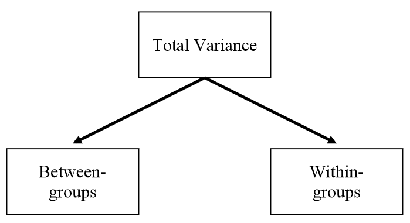

These components of variation are measured using variances, hence the name analysis of variance (ANOVA). Under the null hypothesis that the group means are the same, the between-group variance will be similar to the within group variance. If, however, there are differences between the groups, then the between-group variance will be larger than the within-group variance. The F ratio, which is the test statistic for ANOVA, is obtained by deviding between-group variability by within-group variability.

**Assumptions**

- we have k independent samples, each sample should be randomly selected from the population it represents
- the dependent variable should be approximately normally distributed for each category of the independent variable
- the variances of the k underlying populations represented by the k samples are equal to one another (homogeneity of variance)

**Steps for conducting the test**

**Step 1. Define the null and alternative hypotheses under study**

**H<sub>0</sub>**: all group means in the population are equal (μ<sub>i</sub>=μ<sub>j</sub>, i,j=1,2,3,...)

**H<sub>1</sub>**: at least one group mean in the population differs from the others (μ<sub>i</sub>≠μ<sub>j</sub>, i,j=1,2,3,...)

**Step 2. Calculate the value of the test statistic specific to H<sub>0</sub>**

The calculation of the F ratio involves to calculate the Sum of Squares, SS, the degrees of freedom, df, and finally the variances (Mean Squares, MS). Let's see each of them more analytically:

**Sum of Squares componets**

There are three sums of squares—between-group sum of squares (SS<sub>b</sub>), within-group or error sum of squares (SS<sub>w</sub>), and total sum of squares (SS<sub>t</sub>). Total sum of squares can be partitioned into between sum of squares and within sum of squares, representing the variation due to the independent variable and variation due to individual differences in the score respectively:

**SS<sub>t</sub>=SS<sub>b</sub>+SS<sub>w</sub>**

k: the number of groups (independent samples)

j: the index over groups (*j=1,2,3,..., k*)

n<sub>j</sub>: the sample size of the j<sup>th</sup> group

i: the index over the individuals (*i=1,2,3,..., n<sub>j</sub>)*

x<sub>ij</sub>: the score for an individual, i, within a particular group j

**Degrees of freedom**

Each sum of square (SS<sub>t</sub>, SS<sub>b</sub>, SS<sub>w</sub>) has different degrees of freedom associated with it. The degrees of freedom for the total variance is df<sub>t</sub>=N-1 (where N is the total number of observations in the study, which means that N = n<sub>1</sub> + n<sub>2</sub> + . . . + n<sub>k</sub>), the degrees of freedom for the between-groups variance is df<sub>b</sub>=k-1, the degrees of freedom for the within-groups variance is df<sub>w</sub>=N-k. Obviously, df<sub>t</sub>=df<sub>b</sub>+df<sub>w</sub>.

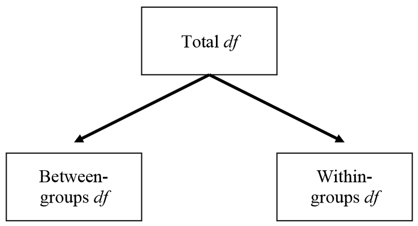

**Means of Squares**

**The F ratio**

An interesting point about the F-ratio is that because it is the ratio of systematic variance to unsystematic variance, if its value is less than 1 then it must, by definition, represent a non-significant effect.

**Equivalency of** **one-way ANOVA** **and** **two-sample t-test**

**Summary Table of one-way ANOVA**

As you have seen hand calculations for ANOVAs require many steps. Fortunatelly, in this course you will be working primarily with R outputs. Statistical softwares compute the F ratio for you and produce what is known as an ANOVA table.

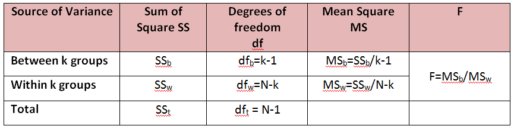

**Step 3. Calculate the p-value from the corresponding F-distribution**

The corresponding p-value for the F statistic can be calculated as the cumulative probability Pr(*F*>F) for a variable *F* that follows an F-distribution with dfb and dfw degrees of freedom. H<sub>0</sub> is rejected if the p-value is less than the significance level alpha (e.g. 0.05).

In practice, after calculating the F statistic, one may resort to online calculators of the F-distribution (e.g. http://stattrek.com/online-calculator/f-distribution.aspx) in order to get the cumulative probability that *F*<F. Then, the p-value is 1-Pr(*F*<F). Statistical software (e.g. R, SPSS) automatically provides the p-value.

**Step 4. Interpretation**

Interpretation of the results. If we obtain a significant result at this initial stage, we may consider performing specific pairwise post-hoc comparisons. We can use one of a number of special tests devised for this purpose (e.g. Bonferroni, Fisher's Least Significant Differences [LSD], Tukey, Scheffé’s, Duncan’s).

**Worked Example**

[figure not shown]

A total of 150 women of different ethnic backgrounds were included in a cross-sectional study of factors related to blood clotting. We compared mean platelet levels in the four groups using a one-way ANOVA. Assume Normality and constant variance between groups (a=0.05) (example from Petrie A. & Sabin C. 2005, Medical Statistics at a Glance, 2nd Ed., p.56-57).

The following table summarizes the data in each group.

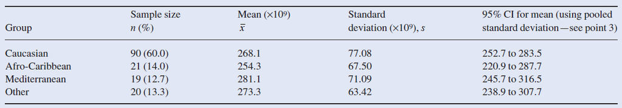

The sums of squares from the ANOVA analysis are:

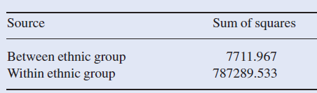

**Step 1. Define the null and alternative hypotheses under study**

**H<sub>0</sub>**: there are no differences in the mean platelet levels in the four groups in the population.

**H<sub>1</sub>**: at least one group mean platelet level differs from the others in the population.

**Step 2. Calculate the value of the test statistic specific to H<sub>0</sub>**

**Degrees of freedom**

The degrees of freedom for the total variance is df<sub>t</sub>=N-1=150-1=149,

the degrees of freedom for the between-groups variance is df<sub>b</sub>=k-1=4-1=3,

the degrees of freedom for the within-groups variance is df<sub>w</sub>=N-k=150-4=146.

Obviously, df<sub>t</sub>=df<sub>b</sub>+df<sub>w</sub>=3+146=149

**Means of Squares**

The estimate of the between-groups variance is given by dividing the SS<sub>b</sub> by the df<sub>b</sub>:

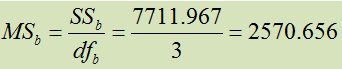

and for within-groups variance:

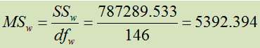

**The F ratio**

**Steps 3 & 4 Compare the value of the test statistic to values from the F-distribution and Interpretation**

Last modified: Sunday, 6 May 2018, 11:51 AM